# Module One Problem Set: Multiple Regression

In this notebook, you have been given a set of steps that will show you how to create a multiple regression model in R. It is very important to run the steps in order. Some steps depend on the outputs of earlier steps. Once you have run all the steps, you will be asked to create your own multiple regression model to help you answer the questions in the Module One Problem Set. You are expected to write the R script yourself to answer these questions.

Reminder: If you have not already reviewed the Problem Set Report template for your Module One Problem Set, be sure to do so now. That will give you an idea of the questions you will need to answer with the outputs of this script. You should use the code you are given as reference when writing your own scripts.

### Step 1: Loading the Data Set

You are an analyst working for a car maker. You have access to a set of data that can be used to study the fuel economy of a car. Car makers are interested in studying factors that are associated with better fuel economy. This data set includes several important variables that are associated with fuel economy. You will use this data set to create models to predict fuel economy.

This block of R code will load the data set from **mtcars.csv** file. Here are the variables contained in the dataset.

[output not shown]

Reference: R data sets. (1974). *Motor trend car road tests *[Data file]. Retrieved from https://www.rdocumentation.org/packages/datasets/versions/3.6.2/topics/mtcars**

Click the code section below and hit the **Run** button above.

```r
# Loading mtcars data set from a mtcars.csv file
mtcars <- read.csv(file='mtcars.csv', header=TRUE, sep=",")

# Converting appropriate variables to factors
mtcars2 <- within(mtcars, {
   vs <- factor(vs)
   am <- factor(am)
   cyl  <- factor(cyl)
   gear <- factor(gear)
   carb <- factor(carb)
})

# Variables and their type
print("Variables")
sapply(mtcars2, class)


# Print the data set
print("dataset")
mtcars2


# Print the first 10 rows
print("head")
head(mtcars2, 10)
```

```
[1] "Variables"
```

**car**

'factor'

**mpg**

'numeric'

**cyl**

'factor'

**disp**

'numeric'

**hp**

'integer'

**drat**

'numeric'

**wt**

'numeric'

**qsec**

'numeric'

**vs**

'factor'

**am**

'factor'

**gear**

'factor'

**carb**

'factor'

```
[1] "dataset"
```

A data.frame: 32 × 12

| car <fct> | mpg <dbl> | cyl <fct> | disp <dbl> | hp <int> | drat <dbl> | wt <dbl> | qsec <dbl> | vs <fct> | am <fct> | gear <fct> | carb <fct> |
| --- | --- | --- | --- | --- | --- | --- | --- | --- | --- | --- | --- |
| Mazda RX4 | 21.0 | 6 | 160.0 | 110 | 3.90 | 2.620 | 16.46 | 0 | 1 | 4 | 4 |
| Mazda RX4 Wag | 21.0 | 6 | 160.0 | 110 | 3.90 | 2.875 | 17.02 | 0 | 1 | 4 | 4 |
| Datsun 710 | 22.8 | 4 | 108.0 | 93 | 3.85 | 2.320 | 18.61 | 1 | 1 | 4 | 1 |
| Hornet 4 Drive | 21.4 | 6 | 258.0 | 110 | 3.08 | 3.215 | 19.44 | 1 | 0 | 3 | 1 |
| Hornet Sportabout | 18.7 | 8 | 360.0 | 175 | 3.15 | 3.440 | 17.02 | 0 | 0 | 3 | 2 |
| Valiant | 18.1 | 6 | 225.0 | 105 | 2.76 | 3.460 | 20.22 | 1 | 0 | 3 | 1 |
| Duster 360 | 14.3 | 8 | 360.0 | 245 | 3.21 | 3.570 | 15.84 | 0 | 0 | 3 | 4 |
| Merc 240D | 24.4 | 4 | 146.7 | 62 | 3.69 | 3.190 | 20.00 | 1 | 0 | 4 | 2 |
| Merc 230 | 22.8 | 4 | 140.8 | 95 | 3.92 | 3.150 | 22.90 | 1 | 0 | 4 | 2 |
| Merc 280 | 19.2 | 6 | 167.6 | 123 | 3.92 | 3.440 | 18.30 | 1 | 0 | 4 | 4 |
| Merc 280C | 17.8 | 6 | 167.6 | 123 | 3.92 | 3.440 | 18.90 | 1 | 0 | 4 | 4 |
| Merc 450SE | 16.4 | 8 | 275.8 | 180 | 3.07 | 4.070 | 17.40 | 0 | 0 | 3 | 3 |
| Merc 450SL | 17.3 | 8 | 275.8 | 180 | 3.07 | 3.730 | 17.60 | 0 | 0 | 3 | 3 |
| Merc 450SLC | 15.2 | 8 | 275.8 | 180 | 3.07 | 3.780 | 18.00 | 0 | 0 | 3 | 3 |
| Cadillac Fleetwood | 10.4 | 8 | 472.0 | 205 | 2.93 | 5.250 | 17.98 | 0 | 0 | 3 | 4 |
| Lincoln Continental | 10.4 | 8 | 460.0 | 215 | 3.00 | 5.424 | 17.82 | 0 | 0 | 3 | 4 |
| Chrysler Imperial | 14.7 | 8 | 440.0 | 230 | 3.23 | 5.345 | 17.42 | 0 | 0 | 3 | 4 |
| Fiat 128 | 32.4 | 4 | 78.7 | 66 | 4.08 | 2.200 | 19.47 | 1 | 1 | 4 | 1 |
| Honda Civic | 30.4 | 4 | 75.7 | 52 | 4.93 | 1.615 | 18.52 | 1 | 1 | 4 | 2 |
| Toyota Corolla | 33.9 | 4 | 71.1 | 65 | 4.22 | 1.835 | 19.90 | 1 | 1 | 4 | 1 |
| Toyota Corona | 21.5 | 4 | 120.1 | 97 | 3.70 | 2.465 | 20.01 | 1 | 0 | 3 | 1 |
| Dodge Challenger | 15.5 | 8 | 318.0 | 150 | 2.76 | 3.520 | 16.87 | 0 | 0 | 3 | 2 |
| AMC Javelin | 15.2 | 8 | 304.0 | 150 | 3.15 | 3.435 | 17.30 | 0 | 0 | 3 | 2 |
| Camaro Z28 | 13.3 | 8 | 350.0 | 245 | 3.73 | 3.840 | 15.41 | 0 | 0 | 3 | 4 |
| Pontiac Firebird | 19.2 | 8 | 400.0 | 175 | 3.08 | 3.845 | 17.05 | 0 | 0 | 3 | 2 |
| Fiat X1-9 | 27.3 | 4 | 79.0 | 66 | 4.08 | 1.935 | 18.90 | 1 | 1 | 4 | 1 |
| Porsche 914-2 | 26.0 | 4 | 120.3 | 91 | 4.43 | 2.140 | 16.70 | 0 | 1 | 5 | 2 |
| Lotus Europa | 30.4 | 4 | 95.1 | 113 | 3.77 | 1.513 | 16.90 | 1 | 1 | 5 | 2 |
| Ford Pantera L | 15.8 | 8 | 351.0 | 264 | 4.22 | 3.170 | 14.50 | 0 | 1 | 5 | 4 |
| Ferrari Dino | 19.7 | 6 | 145.0 | 175 | 3.62 | 2.770 | 15.50 | 0 | 1 | 5 | 6 |
| Maserati Bora | 15.0 | 8 | 301.0 | 335 | 3.54 | 3.570 | 14.60 | 0 | 1 | 5 | 8 |
| Volvo 142E | 21.4 | 4 | 121.0 | 109 | 4.11 | 2.780 | 18.60 | 1 | 1 | 4 | 2 |

```
[1] "head"
```

A data.frame: 10 × 12

| car <fct> | mpg <dbl> | cyl <fct> | disp <dbl> | hp <int> | drat <dbl> | wt <dbl> | qsec <dbl> | vs <fct> | am <fct> | gear <fct> | carb <fct> |
| --- | --- | --- | --- | --- | --- | --- | --- | --- | --- | --- | --- |
| Mazda RX4 | 21.0 | 6 | 160.0 | 110 | 3.90 | 2.620 | 16.46 | 0 | 1 | 4 | 4 |
| Mazda RX4 Wag | 21.0 | 6 | 160.0 | 110 | 3.90 | 2.875 | 17.02 | 0 | 1 | 4 | 4 |
| Datsun 710 | 22.8 | 4 | 108.0 | 93 | 3.85 | 2.320 | 18.61 | 1 | 1 | 4 | 1 |
| Hornet 4 Drive | 21.4 | 6 | 258.0 | 110 | 3.08 | 3.215 | 19.44 | 1 | 0 | 3 | 1 |
| Hornet Sportabout | 18.7 | 8 | 360.0 | 175 | 3.15 | 3.440 | 17.02 | 0 | 0 | 3 | 2 |
| Valiant | 18.1 | 6 | 225.0 | 105 | 2.76 | 3.460 | 20.22 | 1 | 0 | 3 | 1 |
| Duster 360 | 14.3 | 8 | 360.0 | 245 | 3.21 | 3.570 | 15.84 | 0 | 0 | 3 | 4 |
| Merc 240D | 24.4 | 4 | 146.7 | 62 | 3.69 | 3.190 | 20.00 | 1 | 0 | 4 | 2 |
| Merc 230 | 22.8 | 4 | 140.8 | 95 | 3.92 | 3.150 | 22.90 | 1 | 0 | 4 | 2 |
| Merc 280 | 19.2 | 6 | 167.6 | 123 | 3.92 | 3.440 | 18.30 | 1 | 0 | 4 | 4 |

## Step 2: Basic Information on the Data Set

In this step, you will use some R functions to obtain basic information on the data set. This includes obtaining the column (variable) names, the total number of variables, and the total number of rows.

Click the code section below and hit the **Run** button above.

```r
# This prints the column names
print("names")
names(mtcars2)

# Another function that prints the column names
print("colnames")
colnames(mtcars2)

# Total number of columns in the data set
print("ncol")
ncol(mtcars2)

# Total number of rows in the data set
print("nrow")
nrow(mtcars2)
```

```
[1] "names"
```

1. 'car'

2. 'mpg'

3. 'cyl'

4. 'disp'

5. 'hp'

6. 'drat'

7. 'wt'

8. 'qsec'

9. 'vs'

10. 'am'

11. 'gear'

12. 'carb'

```
[1] "colnames"
```

1. 'car'

2. 'mpg'

3. 'cyl'

4. 'disp'

5. 'hp'

6. 'drat'

7. 'wt'

8. 'qsec'

9. 'vs'

10. 'am'

11. 'gear'

12. 'carb'

```
[1] "ncol"
```

12

```
[1] "nrow"
```

32

## Step 3: Histogram

In this step, you will use the **hist** function in R to print the histogram for the variable **mpg** in the data set.

Click the block of code below and hit the **Run** button above.  
NOTE: If the plot is not created, click the code section and hit the **Run** button again.

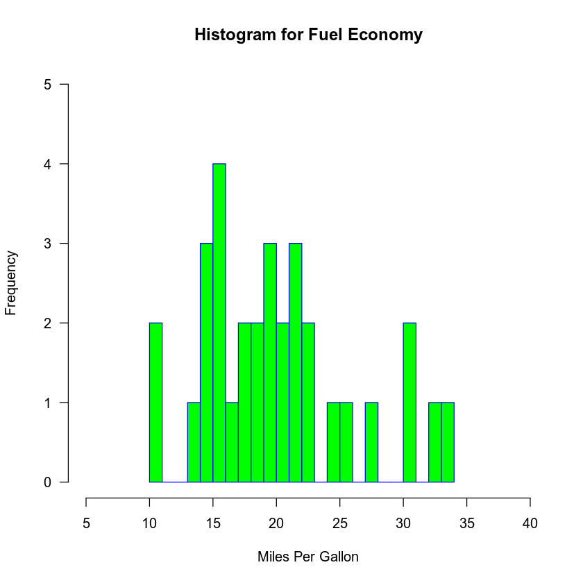

```r
hist(mtcars2$mpg,
     main="Histogram for Fuel Economy",
     xlab="Miles Per Gallon",
     border="blue",
     col="green",
     xlim=c(5,40),
     ylim=c(0,5),
     las=1,
     breaks=20)
```

## Step 4: Scatterplot

In this step, you will use the **plot** function in R to print the scatterplot for the variables **mpg** and **wt** in the data set.

Click the block of code below and hit the **Run** button above.  
NOTE: If the plot is not created, click the code section and hit the **Run** button again.

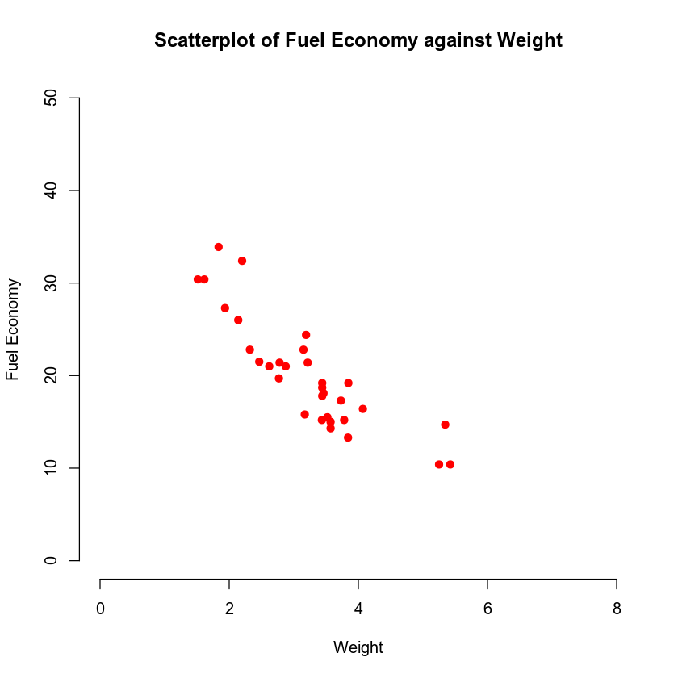

```r
plot(mtcars2$wt, mtcars$mpg,
     main = "Scatterplot of Fuel Economy against Weight",
     xlab = "Weight", ylab = "Fuel Economy",
     xlim=c(0, 8),
     ylim=c(0, 50),
     col="red",
     pch = 19, frame = FALSE)
```

## Step 5: Subsetting Data and Correlation Matrix

In this step, you will create a subset of the original data set to select some variables. Then, you will print the correlation matrix for the selected variables.

Click the block of code below and hit the **Run** button above.

```r
# Selecting mpg, wt, and qsec variables to subset the data
myvars <- c("mpg","wt","qsec")
mtcars_subset <- mtcars2[myvars]

# Print the first 10 rows
print("head")
head(mtcars_subset, 10)

# Print the correlation matrix
print("cor")
corr_matrix <- cor(mtcars_subset, method = "pearson")
round(corr_matrix, 4)
```

```
[1] "head"
```

A data.frame: 10 × 3

| mpg <dbl> | wt <dbl> | qsec <dbl> |
| --- | --- | --- |
| 21.0 | 2.620 | 16.46 |
| 21.0 | 2.875 | 17.02 |
| 22.8 | 2.320 | 18.61 |
| 21.4 | 3.215 | 19.44 |
| 18.7 | 3.440 | 17.02 |
| 18.1 | 3.460 | 20.22 |
| 14.3 | 3.570 | 15.84 |
| 24.4 | 3.190 | 20.00 |
| 22.8 | 3.150 | 22.90 |
| 19.2 | 3.440 | 18.30 |

```
[1] "cor"
```

A matrix: 3 × 3 of type dbl

|  | mpg | wt | qsec |
| --- | --- | --- | --- |
| mpg | 1.0000 | -0.8677 | 0.4187 |
| wt | -0.8677 | 1.0000 | -0.1747 |
| qsec | 0.4187 | -0.1747 | 1.0000 |

## Step 6: Multiple Regression

In this step, you will create a multiple regression model for fuel economy as the response variable, and weight and quarter mile time as predictor variables. You will print summary statistics of this model that will help evaluate the significance and utility of the model.

The general form of this regression model is:

\begin{equation*} \large E(y) = {\beta}_0\ +\ {\beta}_1\ {x}_1\ +\ {\beta}_2\ {x}_2 \end{equation*}

The prediction regression model equation is:

\begin{equation*} \large \hat{y} = \hat{{\beta}_0} +\ \hat{{\beta}_1}\ {x}_1\ +\ \hat{{\beta}_2}\ {x}_2 \end{equation*}

\begin{equation*} \text{where } \hat{y} \text{ is the predicted value of the fuel economy,}\ {x}_1\ \text{is weight,}\ {x}_2\ \text{is quarter mile time} \end{equation*}

\begin{equation*} \hat{{\beta}_0} \text{,} \hspace{0.25cm} \hat{{\beta}_1} \text{, } \hspace{0.25cm} \hat{{\beta}_2} \text{ } \text{ are estimates of} \text{ } {\beta}_0\ \text{,} \hspace{0.25cm} {\beta}_1\ \text{,} \hspace{0.25cm} {\beta}_2\ \text{ respectively } \end{equation*}

Click the block of code below and hit the **Run** button above.

```r
# Create the multiple regression model and print the statistics
model <- lm(mpg ~ wt + qsec, data=mtcars_subset)
summary(model)
```

```
Call:
lm(formula = mpg ~ wt + qsec, data = mtcars_subset)

Residuals:
    Min      1Q  Median      3Q     Max
-4.3962 -2.1431 -0.2129  1.4915  5.7486

Coefficients:
            Estimate Std. Error t value Pr(>|t|)
(Intercept)  19.7462     5.2521   3.760 0.000765 ***
wt           -5.0480     0.4840 -10.430 2.52e-11 ***
qsec          0.9292     0.2650   3.506 0.001500 **
---
Signif. codes:  0 '***' 0.001 '**' 0.01 '*' 0.05 '.' 0.1 ' ' 1

Residual standard error: 2.596 on 29 degrees of freedom
Multiple R-squared:  0.8264,	Adjusted R-squared:  0.8144
F-statistic: 69.03 on 2 and 29 DF,  p-value: 9.395e-12
```

### Interpretation of Beta Estimates

From the output in previous step, the prediction model equation is:  
\begin{equation*} \large \hat{y} = 19.7462\ -\ 5.0480\ {x_1} +\ 0.9292\ {x_2} \end{equation*}

**Interpret the estimated coefficient of weight variable.**

- The estimated coefficient for variable weight is -5.0480. This means that on average, the fuel economy of the car drops (due to the negative sign) by 5.0480 for each 1 unit increase in weight of the car. Note that the variable weight is expressed in 1,000lbs (for example, a weight value of 3.45 in this dataset represents 3,450lbs). A 1 unit increase in weight is equal to 1,000lbs increase, therefore the fuel economy of the car drops by 5.0480 for each 1,000lbs increase in the weight.

## Step 7: Fitted Values

In this step, you will obtain the fitted values of the data set. Recall that the fitted value is just the predicted value of the dependent variable (miles per gallon) for data points from the data set.

Click the block of code below and hit the **Run** button above.

```r
fitted_values <- fitted.values(model)
fitted_values
```

**1**

21.8151085451276

**2**

21.0482240080608

**3**

25.3272787960526

**4**

21.5805692444496

**5**

18.1961141877544

**6**

21.0685880827163

**7**

16.443422914094

**8**

22.227119662579

**9**

25.1237130826411

**10**

19.3854876016019

**11**

19.9430063893429

**12**

15.3689807707991

**13**

17.2711342408795

**14**

17.3904143335647

**15**

9.95129685919368

**16**

8.92427631744801

**17**

8.95138770226528

**18**

26.7321468964226

**19**

28.8024782757959

**20**

28.9742154513748

**21**

25.896198579936

**22**

17.6528959321916

**23**

18.4815295319477

**24**

14.6809126475119

**25**

16.1795574240899

**26**

27.5402192735221

**27**

24.4611474119887

**28**

27.8120717111451

**29**

17.2174904146097

**30**

20.1658811873154

**31**

15.2912174194292

**32**

22.995915104149

## Step 8: Residuals

In this step, you will obtain the residuals. Recall that the residual is the difference between the actual value and the predicted value of the dependent variable (miles per gallon).

Click the block of code below and hit the **Run** button above.

```r
residuals <- residuals(model)
residuals
```

**1**

-0.815108545127597

**2**

-0.0482240080608019

**3**

-2.52727879605257

**4**

-0.180569244449605

**5**

0.503885812245647

**6**

-2.96858808271634

**7**

-2.14342291409402

**8**

2.17288033742101

**9**

-2.32371308264105

**10**

-0.185487601601898

**11**

-2.14300638934293

**12**

1.03101922920092

**13**

0.0288657591205279

**14**

-2.19041433356467

**15**

0.448703140806316

**16**

1.47572368255199

**17**

5.74861229773472

**18**

5.66785310357742

**19**

1.59752172420408

**20**

4.92578454862522

**21**

-4.39619857993604

**22**

-2.15289593219163

**23**

-3.28152953194772

**24**

-1.38091264751193

**25**

3.02044257591012

**26**

-0.240219273522056

**27**

1.53885258801128

**28**

2.58792828885487

**29**

-1.41749041460968

**30**

-0.465881187315388

**31**

-0.291217419429215

**32**

-1.59591510414898

## Step 9: Diagnostic Plots — Residuals against Fitted Values

In this step, you will generate a plot of residuals against fitted values to test the assumption of homoscadasticity.

Click the block of code below and hit the **Run** button above.  
NOTE: If the plot is not created, click the code section and hit the **Run** button again.

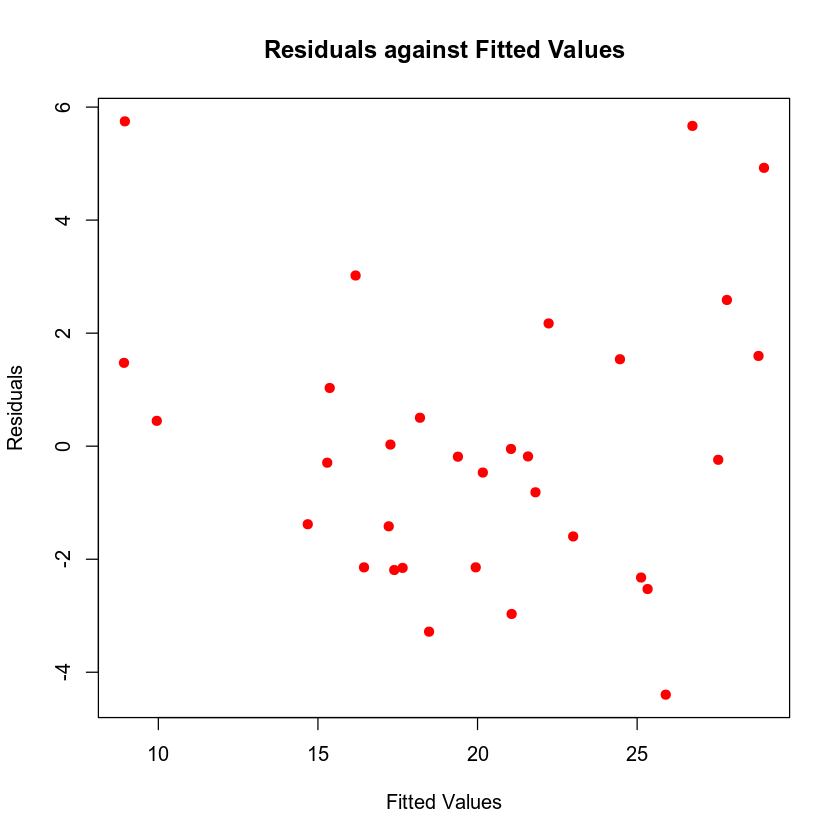

```r
plot(fitted_values, residuals,
     main = "Residuals against Fitted Values",
     xlab = "Fitted Values", ylab = "Residuals",
     col="red",
     pch = 19)
```

## Step 10: Diagnostic Plots — Q-Q Plot

In this step, you will generate a Q-Q plot to test assumptions of normality of the residuals.

Click the block of code below and hit the **Run** button above.  
NOTE: If the plot is not created, click the code section and hit the **Run** button again.

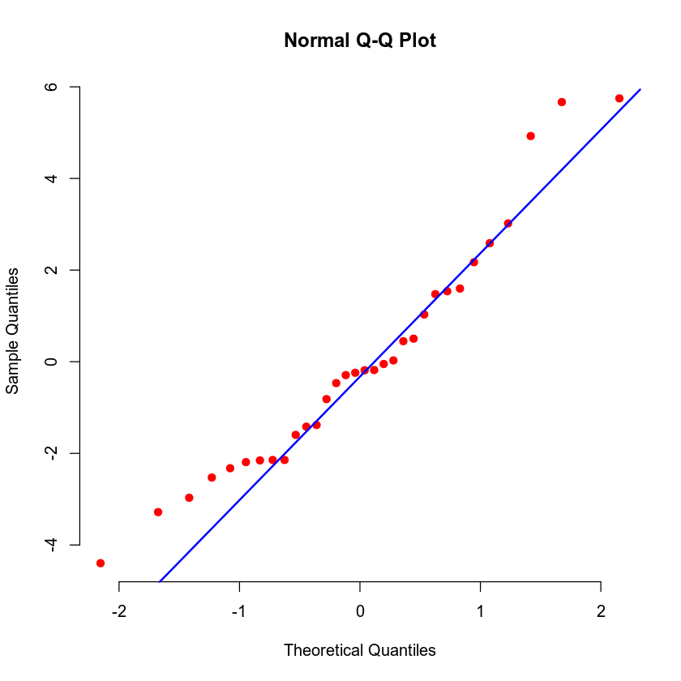

```r
qqnorm(residuals, pch = 19, col="red", frame = FALSE)
qqline(residuals, col = "blue", lwd = 2)
```

## Step 11: Confidence Intervals for Parameter Estimates

In this step, you will use the **confint** function to create 90% confidence intervals for the beta parameter estimates.

Click the block of code below and hit the **Run** button above.

```r
# confidence intervals for model parameters
print("confint")
conf_90_int <- confint(model, level=0.90)
round(conf_90_int, 4)
```

```
[1] "confint"
```

A matrix: 3 × 2 of type dbl

|  | 5 % | 95 % |
| --- | --- | --- |
| (Intercept) | 10.8223 | 28.6701 |
| wt | -5.8704 | -4.2256 |
| qsec | 0.4789 | 1.3795 |

## Step 12: Predictions, Prediction Interval, and Confidence Interval

In this step, you will predict the fuel economy for a car that has a weight of 3.88 and qsec of 22.74. You will also obtain a 90% prediction interval and confidence interval for this prediction. Note that this observation is not from the data set that was used to create this model.

Click the block of code below and hit the **Run** button above.

```r
newdata <- data.frame(wt=3.88, qsec=22.74)

print("prediction interval")
prediction_pred_int <- predict(model, newdata, interval="predict", level=0.90)
round(prediction_pred_int, 4)

print("confidence interval")
prediction_conf_int <- predict(model, newdata, interval="confidence", level=0.90)
round(prediction_conf_int, 4)
```

```
[1] "prediction interval"
```

A matrix: 1 × 3 of type dbl

| fit | lwr | upr |
| --- | --- | --- |
| 21.29 | 16.2269 | 26.3531 |

```
[1] "confidence interval"
```

A matrix: 1 × 3 of type dbl

| fit | lwr | upr |
| --- | --- | --- |
| 21.29 | 18.8049 | 23.7751 |

## Your Code

You have been asked to create a regression model in the Module One Problem Set. Review the Problem Set Report template to see the questions you will be answering about your models.

Use the empty blocks below to write the R code for your model and get outputs. Then use the outputs to answer the questions in your Problem Set Report.

**Note: Use the + (plus) button to add new code blocks or the scissor icon to remove empty code blocks, if needed.**

```r
model <- lm (mpg ~ drat + hp, data = mtcars)
summary(model)
```

```
Call:
lm(formula = mpg ~ drat + hp, data = mtcars)

Residuals:
    Min      1Q  Median      3Q     Max
-5.0369 -2.3487 -0.6034  1.1897  7.7500

Coefficients:
             Estimate Std. Error t value Pr(>|t|)
(Intercept) 10.789861   5.077752   2.125 0.042238 *
drat         4.698158   1.191633   3.943 0.000467 ***
hp          -0.051787   0.009293  -5.573 5.17e-06 ***
---
Signif. codes:  0 '***' 0.001 '**' 0.01 '*' 0.05 '.' 0.1 ' ' 1

Residual standard error: 3.17 on 29 degrees of freedom
Multiple R-squared:  0.7412,	Adjusted R-squared:  0.7233
F-statistic: 41.52 on 2 and 29 DF,  p-value: 3.081e-09
```

## End of Module One Jupyter Notebook

Attach the HTML output along with your problem set report for the Module One Problem Set. The HTML output can be downloaded by clicking **File**, then **Download as**, then **HTML**. Be sure to answer all of the questions in your problem set report.